# Grapevine xf Analysis 2

Daniel Turek

### Updates in Analysis 2

- Vector xf concentration $(\lambda^i_{vector})$ a modelled as a linear function of the source plant xf concentration $(\lambda^i_{plant})$. Further, this linear relationship includes an interaction with genotype, so we separately model this linear relationship for each source plant genotype.
- Tried introducing a probabilistic model for whether the vectors acquire *any* xf bacteria from the source plant, as a function of plant genotype, to account for the “patchiness” of the bacteria in DSF plants. However, this introduced a lack of identfyability between the probability of *transmitting* bacteria to the vectors (not currently in the model) and the probability of *observing* bacteria in the vectors (in the model). So this probabilistic model for transmission from source plants to vectors was removed.
- The model for test plant infection was augmented to include a dependence on plant genotype.
- Simplified the parameterizations of interaction terms, for better interpretability. The mathematical description of the hierarchical model more clearly presents the biological processes for genotype DSF and WT plants. And more clear descriptions for the interpretation of results.
- Make use of a new joint sampling algorithm avaialble in NIMBLE, the automated factor slice sampler (Tibbits et al. 2014). Although this increases runtime, it is extremely effective at sampling highly correlated groups of parameters.
- Predictive nodes are added to predict test plant infection, for the following two cases:
  - genotype = DSF, distance = 0
  - genotype = WT, distance = 0

### Modeling Decisions

##### Vector xf is linear in source plant xf, by genotype (updated v2)

The xf concentration in the vectors $(\lambda^i_{vector})$ is modeled as a linear function of the xf concentration in the source plant $(\lambda^i_{source\ plant})$. However, this linear relationship is distinct for each genotype.

For genotype DSF plants:
$$\lambda^i_{vector} = \beta_5 + \beta_7 \cdot \lambda^i_{source\
plant}$$

This allows us to study how the linear relationship between source plant xf concentration and vector xf concentation varies for each genotype.

##### Source plant and vector observation processes

To model the imperfect detection of xf bacteria in the source plants and vectors, I used a fixed (and separate) probability of detection for each. When measuring the xf concentration in each source plant, there’s a $p_{obs.\ source\ plant}$ probability of a positive detection (e.g., a non-zero measurement).

Similarly, when doing the PCR test to measure the xf concentration in each vector, there’s a $p_{obs.\ vector}$ probability of a positive detection. Each of these probabilities of detection are unknown model parameters.

To implement these detection processes, additional binary latent variables are introduced into the model. The binary-valued $z^i_{source\ plant}$ and $z^i_{vector}$ variables indicate whether a positive detection was made in each source plant or vector.

##### Test plant infection process (updated v2)

Probabiliy of infection for the test plants is modeled (on the logit scale) as a linear function of the vector xf concentration, as well as a constant term for each plant genotype, as:

$$\text{logit}(p^i_{infect}) = \beta_9 \cdot \text{genotype}_{DSF} +
\beta_{10} \cdot \text{genotype}_{WT} + \beta_{11} \cdot \lambda^i_{vector}$$

This sheds light on differences between the two plant genotypes, although there is still not significant effect from the vector xf concentration.

##### Plant Random Effects

The plant random effects $(\alpha_{plant\ ID})$ were removed from the model, since there isn’t enough data to support them. Specifically, with only 97 observations from 51 unique plants, there aren’t enough observations from each plant to identify the random effects. Including them, sampling of the random effects trades off with the genotype fixed effects, and the model never converges.

### Hierarchical Model (updated v2)

$$\begin{align}
\text{Priors:} \\
\beta_{1,...,11} &\sim Normal(0, 10000) \\
p_{obs.\ source\ plant},\ p_{obs.\ vector} &\sim Uniform(0, 1) \\
\ \\
\text{Biological model (DSF source plants):} \\
\log(\lambda^i_{DSF\ source\ plant}) &= \beta_1 + \beta_3 \cdot distance^i \\
\lambda^i_{vector} &= \beta_5 + \beta_7 \cdot \lambda^i_{DSF\ source\ plant} \\
\ \\
\text{Biological model (WT source plants):} \\
\log(\lambda^i_{WT\ source\ plant}) &= \beta_2 + \beta_4 \cdot distance^i \\
\lambda^i_{vector} &= \beta_6 + \beta_8 \cdot \lambda^i_{WT\ source\ plant} \\
\ \\
\text{Source plant observation model:} \\
z^i_{source\ plant} &\sim Bernoulli(p_{obs.\ source\ plant}) \\
xf^i_{source\ plant} &\sim Poisson(z^i_{source\ plant} \cdot \lambda^i_{source\ plant}) \\
\ \\
\text{Vector observation model:} \\
z^i_{vector} &\sim Bernoulli(p_{obs.\ vector}) \\
xf^i_{vector} &\sim Poisson(z^i_{vector} \cdot \lambda^i_{vector}) \\
\ \\
\text{Test plant infection model:} \\
\text{logit}(p^i_{infect}) &= \beta_9 \cdot \text{genotype}_{DSF} +
\beta_{10} \cdot \text{genotype}_{WT} + \beta_{11} \cdot
\lambda^i_{vector} \\
infected^i &\sim Bernoulli(p^i_{infect}) \\
\end{align}$$

### Data Setup

A few manipulations are done of the input data.

```r
dsf <- readRDS('data/dsf_data_for_nimble.rds')   ## original data file
```

We specify covariates:

- $genotype_{dsf}=1$ when genotype = DSF, and 0 otherwise
- $genotype_{wt}=1$ when genotype = WT, and 0 otherwise

```r
constants <- list(
    N = dsf$dsfData$N,
    ##nplant = dsf$dsfData$nplant,
    ##plantID = dsf$dsfData$plantID,
    distance = dsf$dsfData$distance,
    ## in original dataset: genotype 1=DSF, 2=WT
    genotype_dsf = ifelse(dsf$dsfData$genotype==1, 1, 0),   ## indicator for DSF
    genotype_wt  = ifelse(dsf$dsfData$genotype==2, 1, 0)    ## indicator for WT
    ## note: test plants are all WT genotype
)
```

The values of the $xf_{vector}$ data are truncated to be integers, for compatibility with the Poisson distribution.

```r
data <- list(
    xf_source_plant = dsf$dsfData$xf_source_plant,
    xf_vector = floor(dsf$dsfData$xf_vector),   ## change to integers
    infected = dsf$dsfData$infected
)
```

We also create three additional vectors of indicies. Thes contain the indicies of the observed (non-NA) data, for each of $xf_{source\ plant}$, $xf_{vector}$, and $infected$. These will be used in the model to skip creating posterior predictive nodes, which speed up the MCMC and overall mixing considerably.

```r
## indices of observed values for each set of data:
constants$obs_ind_plant <- which(!is.na(data$xf_source_plant))
constants$obs_ind_vector <- which(!is.na(data$xf_vector))
constants$obs_ind_infected <- which(!is.na(data$infected))

## and the counts of each:
constants$N_obs_plant <- length(constants$obs_ind_plant)
constants$N_obs_vector <- length(constants$obs_ind_vector)
constants$N_obs_infected <- length(constants$obs_ind_infected)
```

### Model and MCMC

Use [NIMBLE](https://r-nimble.org/) to build the model and corresponding MCMC algorithm.

```r
library(nimble)

code <- nimbleCode({
    ## priors:
    for(i in 1:11) {
        b[i] ~ dnorm(0, sd=10000)
    }
    p_obs_plant ~ dbeta(1, 1)   ## probability of xf detection in source plant
    p_obs_vector ~ dbeta(1, 1)  ## probability of xf detection in vector
    ## biological model:
    for(i in 1:N) {
        log(lambda_plant[i]) <- b[1]*genotype_dsf[i] + b[2]*genotype_wt[i] + b[3]*distance[i]*genotype_dsf[i] + b[4]*distance[i]*genotype_wt[i]
        lambda_vector[i] <- b[5]*genotype_dsf[i] + b[6]*genotype_wt[i] + b[7]*lambda_plant[i]*genotype_dsf[i] + b[8]*lambda_plant[i]*genotype_wt[i]
    }
    ## only model observed (non-NA) values of xf_source_plant:
    for(iObs in 1:N_obs_plant) {
        z_plant[obs_ind_plant[iObs]] ~ dbern(p_obs_plant)
        xf_source_plant[obs_ind_plant[iObs]] ~ dpois(z_plant[obs_ind_plant[iObs]] * lambda_plant[obs_ind_plant[iObs]])
    }
    ## only model observed (non-NA) values of xf_vector:
    for(iObs in 1:N_obs_vector) {
        z_vector[obs_ind_vector[iObs]] ~ dbern(p_obs_vector)
        xf_vector[obs_ind_vector[iObs]] ~ dpois(z_vector[obs_ind_vector[iObs]] * lambda_vector[obs_ind_vector[iObs]])
    }
    ## only model observed (non-NA) values of infected:
    for(iObs in 1:N_obs_infected) {
        logit(p_infect[obs_ind_infected[iObs]]) <- b[9]*genotype_dsf[obs_ind_infected[iObs]] + b[10]*genotype_wt[obs_ind_infected[iObs]] + b[11]*lambda_vector[obs_ind_infected[iObs]]
        infected[obs_ind_infected[iObs]] ~ dbern(p_infect[obs_ind_infected[iObs]])
    }
    ## genotype DSF predictive nodes:
    log(lambda_plant_dsf) <- b[1]
    lambda_vector_dsf <- b[5] + b[7]*lambda_plant_dsf
    logit(p_infect_dsf) <- b[9] + b[11]*lambda_vector_dsf
    ## genotype WT predictive nodes:
    log(lambda_plant_wt) <- b[2]
    lambda_vector_wt <- b[6] + b[8]*lambda_plant_wt
    logit(p_infect_wt) <- b[10] + b[11]*lambda_vector_wt
})

inits <- list(
    b = c(rep(0,4), 1, 1, 0, 0, rep(0,3)),
    p_obs_plant = 0.5,
    p_obs_vector = 0.5,
    z_plant = rep(1, constants$N),
    z_vector = rep(1, constants$N)
)

Rmodel <- nimbleModel(code, constants, data, inits)

calculate(Rmodel)

conf <- configureMCMC(Rmodel)

## add specialized automated factor slice samplers:
conf$addSampler(c('b[5]','b[7]'), 'AF_slice')
conf$addSampler(c('b[6]','b[8]'), 'AF_slice')
conf$addSampler(c('b[9:11]'),     'AF_slice')

## add monitors for predictive nodes:
conf$addMonitors('p_infect_dsf', 'p_infect_wt')

Rmcmc <- buildMCMC(conf)

system.time(Cmodel <- compileNimble(Rmodel))
```

```
compiling... this may take a minute. Use 'showCompilerOutput = TRUE' to see C++ compiler details.
compilation finished.
   user  system elapsed
 12.424   0.290  12.786
```

```r
system.time(Cmcmc <- compileNimble(Rmcmc, project = Rmodel))
```

```
compiling... this may take a minute. Use 'showCompilerOutput = TRUE' to see C++ compiler details.
compilation finished.
   user  system elapsed
 11.745   0.296  12.121
```

```r
set.seed(0)
system.time(samples <- runMCMC(Cmcmc, 50000, nburnin=10000, nchains=2, returnCodaMCMC=TRUE))
```

```
running chain 1...
|-------------|-------------|-------------|-------------|
|-------------------------------------------------------|
running chain 2...
|-------------|-------------|-------------|-------------|
|-------------------------------------------------------|
   user  system elapsed
 70.132   0.421  71.023
```

### Convergence

We assess convergence of two chains, each with 40,000 post burn-in samples.

The Brooks-Gelman-Rubin diagnostic over two chains of indicates convergence.

```r
library(coda)
```

```r
gelman.diag(samples)
```

```
## Potential scale reduction factors:
##
##              Point est. Upper C.I.
## b[1]                  1          1
## b[2]                  1          1
## b[3]                  1          1
## b[4]                  1          1
## b[5]                  1          1
## b[6]                  1          1
## b[7]                  1          1
## b[8]                  1          1
## b[9]                  1          1
## b[10]                 1          1
## b[11]                 1          1
## p_infect_dsf          1          1
## p_infect_wt           1          1
## p_obs_plant           1          1
## p_obs_vector          1          1
##
## Multivariate psrf
##
## 1
```

The effective sample size of the first chain is satisfactory, with a minimum of 7,000 effectively independent samples from all posterior dimensions, resulting from the 40,000 post burn-in samples.

```r
round(cbind(
    length = apply(samples[[1]], 2, length),
    ESS    = effectiveSize(samples[[1]])
))
```

```
##              length   ESS
## b[1]          40000  9057
## b[2]          40000  7429
## b[3]          40000  9289
## b[4]          40000  7488
## b[5]          40000 40000
## b[6]          40000 40000
## b[7]          40000 39194
## b[8]          40000 40000
## b[9]          40000 40000
## b[10]         40000 41370
## b[11]         40000 40000
## p_infect_dsf  40000 40000
## p_infect_wt   40000 39085
## p_obs_plant   40000 39434
## p_obs_vector  40000 40000
```

### Posterior Mean, Median, and 95% Credible Intervals

```r
res <- round(cbind(
    `CI Lower` = apply(samples[[1]], 2, function(x) quantile(x, 0.025)),
    `Mean`         = apply(samples[[1]], 2, mean),
    `Median`       = apply(samples[[1]], 2, median),
    `CI Upper` = apply(samples[[1]], 2, function(x) quantile(x, 0.975))
), 5)

res
```

```
##                  CI Lower         Mean       Median     CI Upper
## b[1]             17.93634     17.93641     17.93641     17.93647
## b[2]             17.59043     17.59052     17.59052     17.59061
## b[3]             -0.27138     -0.27131     -0.27131     -0.27123
## b[4]             -0.18258     -0.18249     -0.18249     -0.18241
## b[5]         -12253.37196 -12110.48526 -12110.96123 -11968.84272
## b[6]         -24179.09728 -23823.86539 -23823.39269 -23471.85839
## b[7]              0.00034      0.00034      0.00034      0.00035
## b[8]              0.00084      0.00085      0.00085      0.00086
## b[9]             -0.67603      0.42495      0.41893      1.54029
## b[10]            -1.59158     -0.25403     -0.24760      1.05018
## b[11]            -0.00015     -0.00006     -0.00006      0.00002
## p_infect_dsf      0.30537      0.47058      0.46990      0.63834
## p_infect_wt       0.14061      0.26383      0.25958      0.41051
## p_obs_plant       0.37003      0.49997      0.49982      0.62944
## p_obs_vector      0.25781      0.35188      0.35079      0.45166
```

### Interpretations (updated v2)

$\beta_1$, the constant term in the log() predictor for source plant xf concentration in genotype DSF plants, is essentially 17.936. Thus, the baseline xf concentration (at distance=0) in genotype DFS plants is $e^{\beta_1} \approx$ 62,000,000.

$\beta_2$, the constant term in the log() predictor for source plant xf concentration in genotype WT plants, is essentially 17.591, slightly lower than the genotype DSF constant term. Thus, the baseline xf concentration (at distance=0) in genotype WT plants is $e^{\beta_2} \approx$ 44,000,000.

These values of $\beta_1$ and $\beta_2$ imply that for the same $distance$, genotype WT plants will have less xf bacteria than genotype DSF plants. Specifically, lower in the WT plants by a factor of $e^{\beta_2-\beta_1} = e^{-0.346}=$ 0.708.

$\beta_3$, the coefficient of $distance$ in the log() predictor for source plant xf concentration in genotype DSF plants, is essentially -0.271. For every additional unit of distance, the source plant xf concentration in DSF plants will decrease by a factor of $e^{\beta_3}=$ 0.762.

For DSF source plants, $\beta_5$ and $\beta_7$ determine the linear relationship for how xf bacteria is transmitted to vectors, as $\lambda_{vector} = \beta_5 + \beta_7 \cdot \lambda_{source\ plant}$. We are interested in the $\beta_7$ coefficient, which is approximately equal to 0.00034. This means that for DSF source plants, the vector xf concentration is approximately 0.00034 of the source plant xf concentration.

For WT source plants, $\beta_6$ and $\beta_8$ determine the linear relationship for how xf bacteria is transmitted to vectors, as $\lambda_{vector} = \beta_6 + \beta_8 \cdot \lambda_{source\ plant}$. We are interested in the $\beta_8$ coefficient, which is approximately equal to 0.00085. This means that for WT source plants, the vector xf concentration is approximately 0.00085 of the source plant xf concentration. This is a much higher transmission rate from (source plants to vectors) from WT plants relative to DSF plants.

$\beta_{9}$ gives the baseline probability of infection (on the logit scale) for genotype DSF plants. The 95% CI for $\beta_{9}$ is (-0.68, 1.54). Taking the inverse-logit transformation, this gives a 95% CI for the baseline probability of infection for DSF source plants as (0.34, 0.82). This does not take xf concentration in the vector into account.

$\beta_{10}$ gives the baseline probability of infection (on the logit scale) for genotype WT plants. The 95% CI for $\beta_{10}$ is (-1.59, 1.05). Taking the inverse-logit transformation, this gives a 95% CI for the baseline probability of infection for WT source plants as (0.17, 0.74). This does not take xf concentration in the vector into account.

$\beta_{11}$, the coefficient for vector xf level in the logit() predictor for test plant infection, is not significantly different from 0, with 95% CI (-0.00015, 0.00002).

$p_{obs.\ source\ plant}$, the probability of xf detection in source plants, is bounded by the 95% CI (0.37, 0.63).

$p_{obs.\ vector}$, the probability of xf detection in vectors, is bounded by the 95% CI (0.26, 0.45).

The predictive nodes give the best idea of the probability of infection, from either DSF or WT source plants, using distance = 0. These estimates take all model parameters and biological processes into account.

- Probability of infection for genotype DSF is in the 95% CI: (0.31, 0.64), with median = 0.47.
- Probability of infection for genotype WT is in the 95% CI: (0.14, 0.41), with median = 0.26.

### Posterior Density Plots

Overlay the predictive distributions for test plant infection:

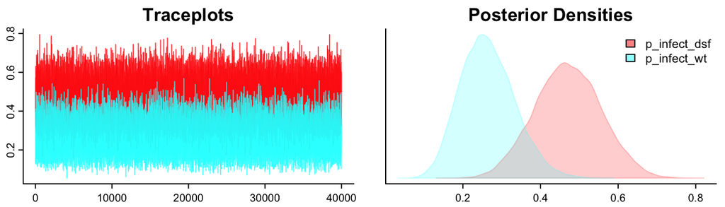

```r
samplesPlot(samples[[1]], c('p_infect_dsf','p_infect_wt'), height=2)
```

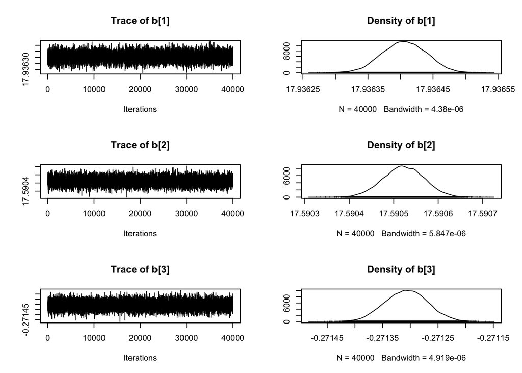

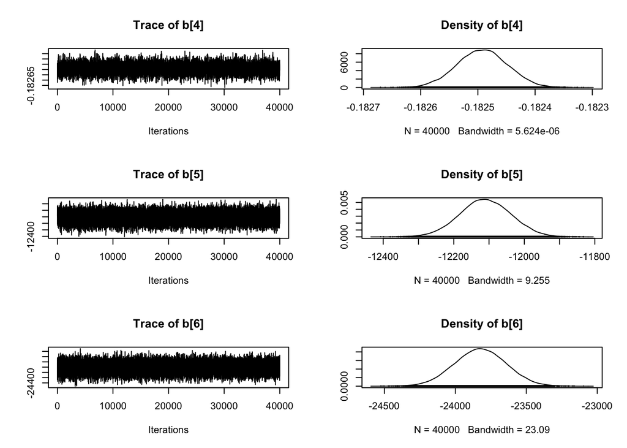

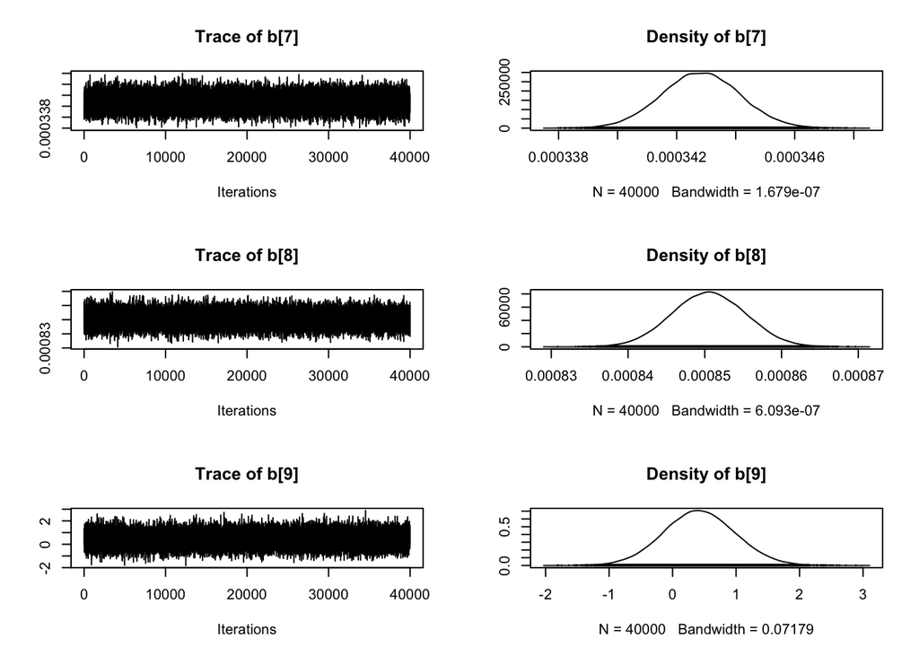

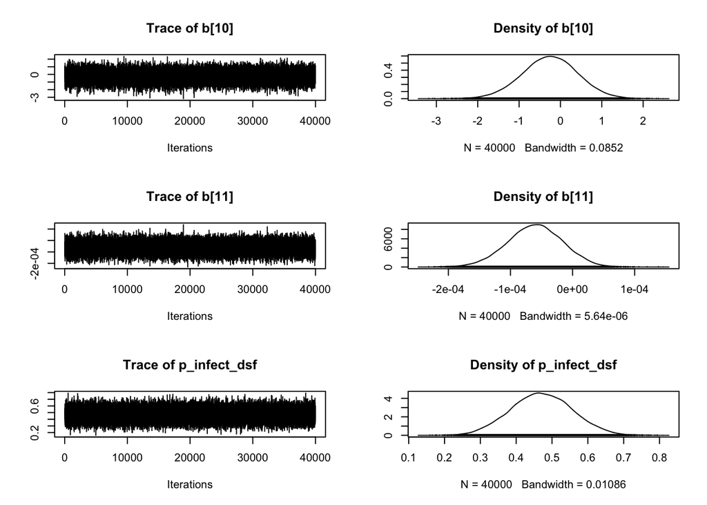

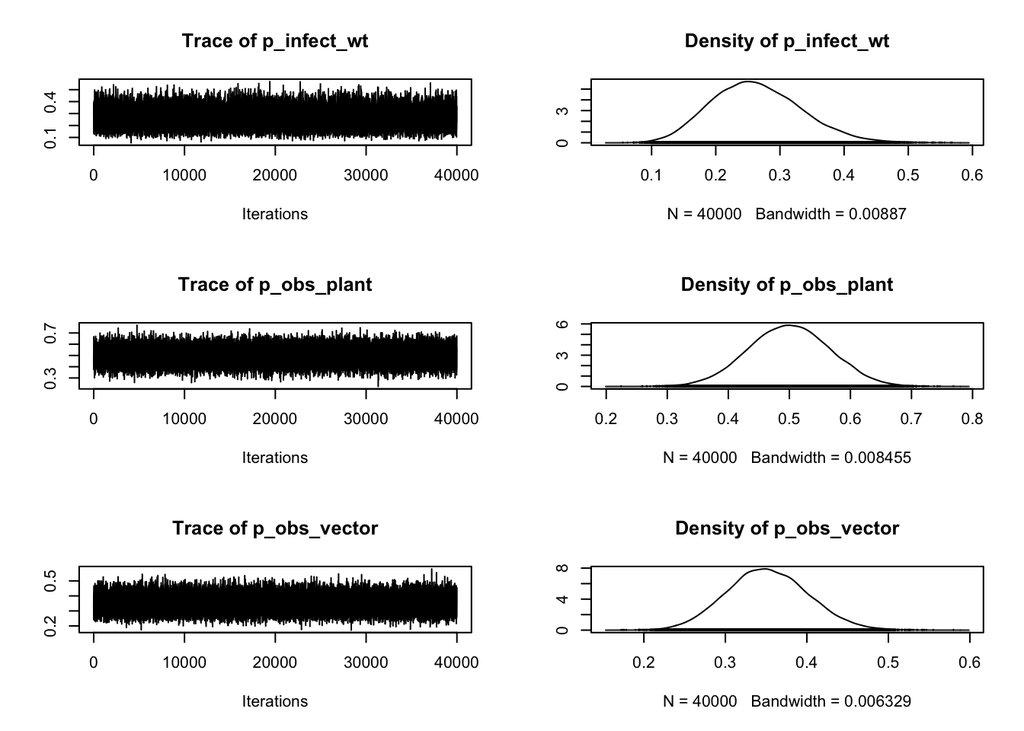

```r
plot(samples[[1]], ask = FALSE)
```

### References

Tibbits, Matthew M, Chris Groendyke, Murali Haran, and John C Liechty. 2014. “Automated Factor Slice Sampling.” *Journal of Computational and Graphical Statistics* 23 (2). Taylor & Francis: 543–63.